# Practical Machine Learning Course Project

#### Author: Chong Kean Meng

## Introduction

Using devices such as Jawbone Up, Nike FuelBand, and Fitbit it is now possible to collect a large amount of data about personal activity relatively inexpensively. These type of devices are part of the quantified self movement - a group of enthusiasts who take measurements about themselves regularly to improve their health, to find patterns in their behavior. One thing that people regularly do is quantify how much of a particular activity they do, but they rarely quantify how well they do it. They were asked to perform barbell lifts correctly and incorrectly in 5 different ways. The project goal is to use data from accelerometers on the belt, forearm, arm, and dumbell of 6 participants to predict the manner in which they did the exercise.

## Data Processing

```r
#Acquire Training and Test Data
if (!file.exists("pml-training.csv")) {
    download.file("http://d396qusza40orc.cloudfront.net/predmachlearn/pml-training.csv",
                  destfile = "pml-training.csv")
}
if (!file.exists("pml-testing.csv")) {
    download.file("http://d396qusza40orc.cloudfront.net/predmachlearn/pml-testing.csv", destfile = "pml-testing.csv")
}

#Load data
train <- read.csv("pml-training.csv", na.strings=c("#DIV/0!"))
test <- read.csv("pml-testing.csv", na.strings=c("#DIV/0!"))
dim(train)
```

```
## [1] 19622   160
```

```r
dim(test)
```

```
## [1]  20 160
```

Clean the data by removing missing values and unused variables.

```r
sum(complete.cases(train))
```

```
## [1] 0
```

```r
##Remove columns that contain NA missing values.
train <- train[, colSums(is.na(train)) == 0]
test <- test[, colSums(is.na(test)) == 0]

## Remove columns that do not contribute to the accelerometer measurements.
classe <- train$classe
trainRemove <- grepl("^X|timestamp|window", names(train))
train <- train[, !trainRemove]
trainCleaned <- train[, sapply(train, is.numeric)]
trainCleaned$classe <- classe
testRemove <- grepl("^X|timestamp|window", names(test))
test <- test[, !testRemove]
testCleaned <- test[, sapply(test, is.numeric)]
dim(trainCleaned)
```

```
## [1] 19622    53
```

```r
dim(testCleaned)
```

```
## [1] 20 53
```

```r
#Verify there is no zero covariates as they are not likely to be good predictors
myDataNZV <- nearZeroVar(train, saveMetrics=TRUE)
myDataNZV
```

```
##                            freqRatio percentUnique zeroVar   nzv
## user_name                   1.100679    0.03057792   FALSE FALSE
## roll_belt                   1.101904    6.77810621   FALSE FALSE
## pitch_belt                  1.036082    9.37722964   FALSE FALSE
## yaw_belt                    1.058480    9.97349913   FALSE FALSE
## total_accel_belt            1.063160    0.14779329   FALSE FALSE
## max_roll_belt            1746.909091    0.99887881   FALSE  TRUE
## max_picth_belt            192.160000    0.11721537   FALSE  TRUE
## min_roll_belt            1601.333333    0.94281928   FALSE  TRUE
## min_pitch_belt            168.561404    0.08663745   FALSE  TRUE
## amplitude_roll_belt       480.400000    0.75935175   FALSE  TRUE
## amplitude_pitch_belt       88.962963    0.07134849   FALSE  TRUE
## var_total_accel_belt      164.239316    0.33635715   FALSE  TRUE
## avg_roll_belt            1201.000000    0.97849353   FALSE  TRUE
## stddev_roll_belt          362.566038    0.35674243   FALSE  TRUE
## var_roll_belt             152.507937    0.49434308   FALSE  TRUE
## avg_pitch_belt           1746.909091    1.09570890   FALSE  TRUE
## stddev_pitch_belt         266.888889    0.22423810   FALSE  TRUE
## var_pitch_belt            161.478992    0.32616451   FALSE  TRUE
## avg_yaw_belt             1601.333333    1.22821323   FALSE  TRUE
## stddev_yaw_belt           231.518072    0.30068291   FALSE  TRUE
## var_yaw_belt              291.151515    0.74406279   FALSE  TRUE
## gyros_belt_x                1.058651    0.71348486   FALSE FALSE
## gyros_belt_y                1.144000    0.35164611   FALSE FALSE
## gyros_belt_z                1.066214    0.86127816   FALSE FALSE
## accel_belt_x                1.055412    0.83579655   FALSE FALSE
## accel_belt_y                1.113725    0.72877383   FALSE FALSE
## accel_belt_z                1.078767    1.52379982   FALSE FALSE
## magnet_belt_x               1.090141    1.66649679   FALSE FALSE
## magnet_belt_y               1.099688    1.51870350   FALSE FALSE
## magnet_belt_z               1.006369    2.32901845   FALSE FALSE
## roll_arm                   52.338462   13.52563449   FALSE FALSE
## pitch_arm                  87.256410   15.73234125   FALSE FALSE
## yaw_arm                    33.029126   14.65701763   FALSE FALSE
## total_accel_arm             1.024526    0.33635715   FALSE FALSE
## var_accel_arm            1746.909091    2.01814290   FALSE  TRUE
## avg_roll_arm              249.558442    1.68688207   FALSE  TRUE
## stddev_roll_arm           249.558442    1.68688207   FALSE  TRUE
## var_roll_arm              249.558442    1.68688207   FALSE  TRUE
## avg_pitch_arm             249.558442    1.68688207   FALSE  TRUE
```

[output cut: 67 more lines]

```
## stddev_pitch_forearm      231.518072    1.65120783   FALSE  TRUE
## var_pitch_forearm         231.518072    1.65630415   FALSE  TRUE
## avg_yaw_forearm           231.518072    1.65630415   FALSE  TRUE
## stddev_yaw_forearm        226.070588    1.64611151   FALSE  TRUE
## var_yaw_forearm           226.070588    1.64611151   FALSE  TRUE
## gyros_forearm_x             1.059273    1.51870350   FALSE FALSE
## gyros_forearm_y             1.036554    3.77637346   FALSE FALSE
## gyros_forearm_z             1.122917    1.56457038   FALSE FALSE
## accel_forearm_x             1.126437    4.04647844   FALSE FALSE
## accel_forearm_y             1.059406    5.11160942   FALSE FALSE
## accel_forearm_z             1.006250    2.95586586   FALSE FALSE
## magnet_forearm_x            1.012346    7.76679238   FALSE FALSE
## magnet_forearm_y            1.246914    9.54031189   FALSE FALSE
## magnet_forearm_z            1.000000    8.57710733   FALSE FALSE
## classe                      1.469581    0.02548160   FALSE FALSE
```

## Cross Validation

The pml.training data will be used to train the model. To estimate the pml.testing data accuracy, the pml.training data is splitted into 60% (Training set) and 40% (Test set).

```r
set.seed(12345) #for reproducible purpose
inTrain <- createDataPartition(y=trainCleaned$classe, p=0.6, list=FALSE)
mytrain <- trainCleaned[inTrain, ]
mytest <- trainCleaned[-inTrain, ]
```

```r
dim(mytrain)
```

```
## [1] 11776    53
```

```r
dim(mytest)
```

```
## [1] 7846   53
```

## Determine Prediction Model

#### Comparison of prediction models - Regression and Classification Trees and Random Forest

### Regression and Classification Trees

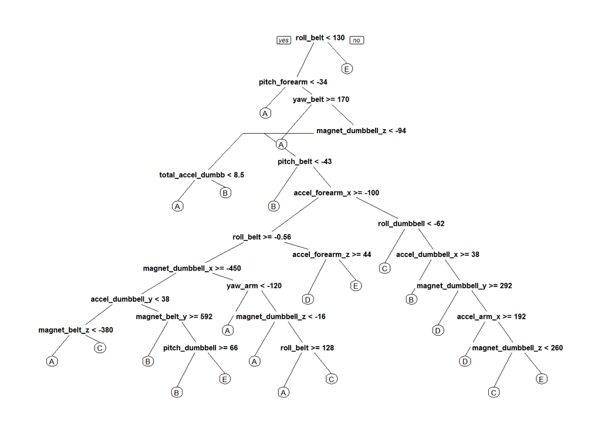

```r
modelRpart <- rpart(classe ~ ., data=mytrain, method="class")
prp(modelRpart)
```

```r
predictRpart <- predict(modelRpart, mytest, type = "class")
confusionMatrix(mytest$classe, predictRpart)
```

```
## Confusion Matrix and Statistics
##
##           Reference
## Prediction    A    B    C    D    E
##          A 1879   56  105  155   37
##          B  260  759  340  132   27
##          C   30   88 1226   23    1
##          D   69   34  354  807   22
##          E   66   54  234   57 1031
##
## Overall Statistics
##
##                Accuracy : 0.7267
##                  95% CI : (0.7167, 0.7366)
##     No Information Rate : 0.2937
##     P-Value [Acc > NIR] : < 2.2e-16
##
##                   Kappa : 0.6546
##  Mcnemar's Test P-Value : < 2.2e-16
##
## Statistics by Class:
##
##                      Class: A Class: B Class: C Class: D Class: E
## Sensitivity            0.8155  0.76589   0.5427   0.6874   0.9222
## Specificity            0.9363  0.88928   0.9746   0.9282   0.9389
## Pos Pred Value         0.8418  0.50000   0.8962   0.6275   0.7150
## Neg Pred Value         0.9243  0.96334   0.8405   0.9441   0.9864
## Prevalence             0.2937  0.12631   0.2879   0.1496   0.1425
## Detection Rate         0.2395  0.09674   0.1563   0.1029   0.1314
## Detection Prevalence   0.2845  0.19347   0.1744   0.1639   0.1838
## Balanced Accuracy      0.8759  0.82759   0.7587   0.8078   0.9305
```

Decision Tree has an accuracy rate of **0.7267** and Out of Sample Error rate is **0.2733**

### Random Forest

```r
controlRf <- trainControl(method="cv", 10)
modelRf <- train(classe ~ ., data=mytrain, method="rf", trControl=controlRf, ntree=250)
modelRf
```

```
## Random Forest
##
## 11776 samples
##    52 predictor
##     5 classes: 'A', 'B', 'C', 'D', 'E'
##
## No pre-processing
## Resampling: Cross-Validated (10 fold)
##
## Summary of sample sizes: 10599, 10599, 10597, 10598, 10600, 10599, ...
##
## Resampling results across tuning parameters:
##
##   mtry  Accuracy   Kappa      Accuracy SD  Kappa SD
##    2    0.9896404  0.9868944  0.003015941  0.003816313
##   27    0.9904047  0.9878623  0.005081407  0.006427217
##   52    0.9866676  0.9831324  0.006243537  0.007901889
##
## Accuracy was used to select the optimal model using  the largest value.
## The final value used for the model was mtry = 27.
```

```r
predictRf <- predict(modelRf, mytest)
confusionMatrix(mytest$classe, predictRf)
```

```
## Confusion Matrix and Statistics
##
##           Reference
## Prediction    A    B    C    D    E
##          A 2228    4    0    0    0
##          B    9 1502    7    0    0
##          C    0    5 1358    5    0
##          D    0    0   20 1263    3
##          E    0    1    3    5 1433
##
## Overall Statistics
##
##                Accuracy : 0.9921
##                  95% CI : (0.9899, 0.9939)
##     No Information Rate : 0.2851
##     P-Value [Acc > NIR] : < 2.2e-16
##
##                   Kappa : 0.99
##  Mcnemar's Test P-Value : NA
##
## Statistics by Class:
##
##                      Class: A Class: B Class: C Class: D Class: E
## Sensitivity            0.9960   0.9934   0.9784   0.9921   0.9979
## Specificity            0.9993   0.9975   0.9985   0.9965   0.9986
## Pos Pred Value         0.9982   0.9895   0.9927   0.9821   0.9938
## Neg Pred Value         0.9984   0.9984   0.9954   0.9985   0.9995
## Prevalence             0.2851   0.1927   0.1769   0.1622   0.1830
## Detection Rate         0.2840   0.1914   0.1731   0.1610   0.1826
## Detection Prevalence   0.2845   0.1935   0.1744   0.1639   0.1838
## Balanced Accuracy      0.9976   0.9954   0.9884   0.9943   0.9983
```

> Between the two models, Random Forest is a better Prediction Model.

## Predicting Test Data Set using Random Forest

```r
outcome = predict(modelRf, testCleaned)

pml_write_files = function(x){
  n = length(x)
  for(i in 1:n){
    filename = paste0("problem_id_",i,".txt")
    write.table(x[i],file=filename,quote=FALSE,row.names=FALSE,col.names=FALSE)
  }
}

pml_write_files(outcome)
```